# Knowledge Graphs and Semantic Technologies -- KG measures and clustering tutorial

First, make sure you have networkx installed, here you can find the [documentation](https://networkx.org/documentation/stable/reference/index.html).

```python
## Uncomment if you do not have networkx installed (you should have it installed from the RDFS tutorial)
#import sys
#!{sys.executable} -m pip install networkx

import pandas as pd
import rdflib
from rdflib import Literal
from rdflib.namespace import DC, FOAF

import networkx as nx
from owlready2 import *
```

In this tutorial, we will focus on how to characterize an ontology or knowledge graph.

```python
ontology = rdflib.Graph()
ontology.parse("data/my_music_ontology_inferred.owl")
```

```
<Graph identifier=N051470c071eb42f7a05a4c77759fdd91 (<class 'rdflib.graph.Graph'>)>
```

## 1. Basic (ontology) measures

Let's first focus on calculating basic measures:

- number of classes
- number of properties
- number of individuals
- number of triples
- number of entities (classes, individuals, etc. anything that can be places in the subject possition in a triple/axiom)

We start by counting the number of classes in the ontology. This can be done using a SPARQL query. We want to get the unique classes used in the ontology.

This query gives as all the classes that also have a definition in the ontology. However, this does not have to equal the number of classes actually used by individuals. Hence, you need to be very specific about what the number you are retriving represents.

```python
answer = list(ontology.query(
    'PREFIX owl: <http://www.w3.org/2002/07/owl#> SELECT DISTINCT ?s WHERE { ?s rdf:type owl:Class. FILTER isURI(?s) }'
))
print("Number of classes: {f}".format(f=len(answer)))
for r in answer:
    print(r)
```

```
Number of classes: 9
(rdflib.term.URIRef('http://example.org/music_ontology.owl#Album'),)
(rdflib.term.URIRef('http://example.org/music_ontology.owl#Artist'),)
(rdflib.term.URIRef('http://example.org/music_ontology.owl#Song'),)
(rdflib.term.URIRef('http://example.org/music_ontology.owl#Person'),)
(rdflib.term.URIRef('http://example.org/music_ontology.owl#Genre'),)
(rdflib.term.URIRef('http://example.org/music_ontology.owl#SubGenre'),)
(rdflib.term.URIRef('http://example.org/music_ontology.owl#SoloArtist'),)
(rdflib.term.URIRef('http://example.org/music_ontology.owl#ArtistType'),)
(rdflib.term.URIRef('http://example.org/music_ontology.owl#CollaboratingArtist'),)
```

Even though we used a query, a lot of this information can also be retrieved with owlready2. For example, the number of classes can be retrieved with the function onto.classes(). It returns all classes in the ontology. We try it below.

```python
onto_file = "data/my_music_ontology_inferred.owl"
or_ontology = get_ontology(onto_file).load()
answer = list(or_ontology.classes())

print("Number of classes: {f}".format(f=len(answer)))
for r in answer:
    print(r)
```

```
Number of classes: 9
my_music_ontology_inferred.Album
my_music_ontology_inferred.Artist
my_music_ontology_inferred.Song
my_music_ontology_inferred.Genre
my_music_ontology_inferred.Person
my_music_ontology_inferred.SubGenre
my_music_ontology_inferred.SoloArtist
my_music_ontology_inferred.ArtistType
my_music_ontology_inferred.CollaboratingArtist
```

```python
ind = list(or_ontology.individuals())
print(len(ind))
```

```
6
```

### Exercise 1

Get the following metrics from the Hybrid Intelligence ontology, using queries and check your answer using owlready2 functions. WARNING: loading the .ttl file might cause the parsing to break. You can pre-process the file by loading it with rdflib and serializing it into ntriples/nt.

- number of properties
- number of individuals
- number of triples
- number of entities (classes, individuals, etc. anything that can be places in the subject possition in a triple/axiom)

```python
ttl_path = "data/hi_ontology.ttl"
nt_path  = "data/hi_ontology.nt"

g = rdflib.Graph()
g.parse(ttl_path, format="turtle")
g.serialize(destination=nt_path, format="nt")

hi_g = rdflib.Graph()
hi_g.parse(nt_path, format="nt")

print(f'number of triples: {len(hi_g)}')

#number of individuals
q_individuals = """
PREFIX owl: <http://www.w3.org/2002/07/owl#>
SELECT (COUNT(DISTINCT ?i) AS ?n)
WHERE {
  ?i a owl:NamedIndividual .
}
"""
print(f'number of individuals: {int(list(hi_g.query(q_individuals))[0][0])}')

#number of entities
q_entities = """
SELECT (COUNT(DISTINCT ?s) AS ?n)
WHERE {
  ?s ?p ?o .
  FILTER(isIRI(?s))
}
"""
int(list(hi_g.query(q_entities))[0][0])
print(f'number of enteties: {int(list(hi_g.query(q_entities))[0][0])}')

q_properties = """
PREFIX owl: <http://www.w3.org/2002/07/owl#>
SELECT (COUNT(DISTINCT ?p) AS ?n)
WHERE {
  { ?p a owl:ObjectProperty . }
  UNION
  { ?p a owl:DatatypeProperty . }
  UNION
  { ?p a owl:AnnotationProperty . }
}
"""
print(f'number of properties: {int(list(hi_g.query(q_properties))[0][0])}')
```

```
number of triples: 114
number of individuals: 28
number of enteties: 57
number of properties: 13
```

Checking metrics with owlready2

```python
onto = get_ontology("data/hi_ontology.nt").load()
onto.save(file="owlready_export.nt", format="ntriples")

g2 = rdflib.Graph()
g2.parse("owlready_export.nt", format="nt")

print(f'number of properties: {len(list(onto.properties()))}')
print(f'number of triples: {len(g2)}')
```

```
number of properties: 13
number of triples: 114
```

```python
print(f'number of individuals: {len(list(onto.individuals()))}')
```

```
number of individuals: 28
```

```python
entities_iris = {s for (s,p,o) in g2 if isinstance(s, rdflib.term.URIRef)}
print(f'number of enteties: {len(entities_iris)}')
```

```
number of enteties: 57
```

## 2. Converting KGs into Gs

To make use of graph measure, we need to convert our ontology into a mathematical graph networkx.

We first need to remove all the logics before we can do the conversion. We are interested in keeping the following things:

- individual
- classes
- relationships between individuals and classes

What we need to remove is:

- restrictions
- domain/range
- property definitions

There is two ways for us to do it: we can either remove the information from the existing graph, or create a new graph using only the information we are interested in. Depending on the size and complexity of your knowledge graph, one way will be more preferrable than the other. You also need to consider if you want to keep the inferred information in your graph after conversion or not. Here, we want to keep the inferred information, but that is depended on the task you will then execute (for link prediction, you probably want the uninferred ontology and use the inferred information as a test set)

rdflib comes with a function that lets us convert a rdflib graph into an networkx graph.

```python
from rdflib.extras.external_graph_libs import rdflib_to_networkx_digraph
nx_graph = rdflib_to_networkx_digraph(ontology)

list(nx_graph.nodes())
```

```
[rdflib.term.BNode('Nfc07a975edea44ff9bc7832dbdf8dbdf'),
 rdflib.term.BNode('N0987167a11004ce3b38160c8ca6bc9c2'),
 rdflib.term.URIRef('http://example.org/music_ontology.owl#authorOf'),
 rdflib.term.URIRef('http://example.org/music_ontology.owl#Song'),
 rdflib.term.URIRef('http://example.org/music_ontology.owl#Album'),
 rdflib.term.URIRef('http://www.w3.org/2002/07/owl#Thing'),
 rdflib.term.URIRef('http://example.org/music_ontology.owl#writtenBy'),
 rdflib.term.URIRef('http://example.org/music_ontology.owl#hasFan'),
 rdflib.term.URIRef('http://example.org/music_ontology.owl#Artist'),
 rdflib.term.URIRef('http://example.org/music_ontology.owl#Drake'),
 rdflib.term.URIRef('http://example.org/music_ontology.owl#SoloArtist'),
 rdflib.term.URIRef('http://example.org/music_ontology.owl#CollaboratingArtist'),
 rdflib.term.URIRef('http://example.org/music_ontology.owl#albumID'),
 rdflib.term.URIRef('http://www.w3.org/2002/07/owl#Class'),
 rdflib.term.URIRef('http://example.org/music_ontology.owl#collaboratesWith'),
 rdflib.term.URIRef('http://www.w3.org/2002/07/owl#SymmetricProperty'),
 rdflib.term.URIRef('http://example.org/music_ontology.owl#miss_lauren_hill'),
 rdflib.term.BNode('Nd9d1fde78a534f0c9877466e86760900'),
 rdflib.term.URIRef('http://example.org/music_ontology.owl#kill_bill'),
 rdflib.term.URIRef('http://example.org/music_ontology.owl#createdBy'),
 rdflib.term.URIRef('http://www.w3.org/2002/07/owl#ObjectProperty'),
 rdflib.term.URIRef('http://www.w3.org/2002/07/owl#Restriction'),
 rdflib.term.URIRef('http://example.org/music_ontology.owl#hasArtist'),
 rdflib.term.URIRef('http://example.org/music_ontology.owl#hasName'),
 rdflib.term.URIRef('http://www.w3.org/2002/07/owl#DatatypeProperty'),
 rdflib.term.BNode('N72da62f661674c5e836dcc1c71b71733'),
 rdflib.term.URIRef('http://example.org/music_ontology.owl#SZA'),
 rdflib.term.URIRef('http://example.org/music_ontology.owl#isOfAlbum'),
 rdflib.term.URIRef('http://example.org/music_ontology.owl#Person'),
 rdflib.term.URIRef('http://www.w3.org/2002/07/owl#NamedIndividual'),
 rdflib.term.URIRef('http://example.org/music_ontology.owl#SOS'),
 rdflib.term.URIRef('http://example.org/music_ontology.owl#ArtistType'),
 rdflib.term.URIRef('http://example.org/music_ontology.owl#hasArtistSong'),
 rdflib.term.URIRef('http://example.org/music_ontology.owl#isFanOf'),
 rdflib.term.BNode('N81c00e8cf75b441782554913e91c85fb'),
 rdflib.term.URIRef('http://www.w3.org/2001/XMLSchema#string'),
 rdflib.term.URIRef('http://example.org/music_ontology.owl#SubGenre'),
 rdflib.term.URIRef('http://example.org/music_ontology.owl#Genre'),
 rdflib.term.URIRef('http://www.w3.org/1999/02/22-rdf-syntax-ns#nil'),
 rdflib.term.URIRef('http://example.org/music_ontology.owl#albumName'),
 rdflib.term.URIRef('http://example.org/music_ontology.owl#isOfGenre'),
 rdflib.term.URIRef('http://example.org/music_ontology.owl#artistName'),
 rdflib.term.URIRef('http://example.org/music_ontology.owl#followers'),
 rdflib.term.URIRef('http://example.org/music_ontology.owl#Fie'),
 rdflib.term.URIRef('http://www.w3.org/2002/07/owl#FunctionalProperty'),
 rdflib.term.Literal('1', datatype=rdflib.term.URIRef('http://www.w3.org/2001/XMLSchema#nonNegativeInteger')),
 rdflib.term.URIRef('http://example.org/music_ontology.owl'),
 rdflib.term.URIRef('http://www.w3.org/2002/07/owl#Ontology'),
 rdflib.term.URIRef('http://www.w3.org/2001/XMLSchema#integer')]
```

As we can see, there are some blank nodes which were convered into the graph that are not very useful for us at this stage. To analyse the graph as a mathematical graph, we don't want the class restrictions or property range and domain definision in our graph, as we are not doing any reasoning anymore.

Often times, it is easier to create a new graph than removeing already modeled information from the graph. Instead of continuing with the ontology, we will create a graph from the metadata provided in 'data/musicoset_metadata', but will adhere to the ontology from before (use the property and class names,etc.)

```python
csv_albums =  pd.read_csv('data/musicoset_metadata/albums.csv',sep='\t')
print(csv_albums.columns)
csv_artists =  pd.read_csv('data/musicoset_metadata/artists.csv',sep='\t')
print(csv_artists.columns)
csv_songs =  pd.read_csv('data/musicoset_metadata/songs.csv',sep='\t')
print(csv_songs.columns)
csv_tracks =  pd.read_csv('data/musicoset_metadata/tracks.csv',sep='\t')
print(csv_tracks.columns)
```

```
Index(['album_id', 'name', 'billboard', 'artists', 'popularity',
       'total_tracks', 'album_type', 'image_url'],
      dtype='str')
Index(['artist_id', 'name', 'followers', 'popularity', 'artist_type',
       'main_genre', 'genres', 'image_url'],
      dtype='str')
Index(['song_id', 'song_name', 'billboard', 'artists', 'popularity',
       'explicit', 'song_type'],
      dtype='str')
Index(['song_id', 'album_id', 'track_number', 'release_date',
       'release_date_precision'],
      dtype='str')
```

```python
# We have prepared a simplified ontology to use in this tutorial
# This ontology doesn't have any restrictions or domain/range definitions
# this is to avoid blank nodes when converting to networx
music_onto = rdflib.Graph()
music_onto.parse("data/music_onto_simple.rdf")

nx_music = rdflib_to_networkx_digraph(music_onto)
list(nx_music.nodes())
```

```
[rdflib.term.URIRef('http://test.org/myonto.owl#Song'),
 rdflib.term.URIRef('http://www.w3.org/2002/07/owl#Thing'),
 rdflib.term.URIRef('http://test.org/myonto.owl#locatedIn'),
 rdflib.term.URIRef('http://www.w3.org/2002/07/owl#ObjectProperty'),
 rdflib.term.URIRef('http://test.org/myonto.owl#bandMember'),
 rdflib.term.URIRef('http://test.org/myonto.owl#Artist'),
 rdflib.term.URIRef('http://test.org/myonto.owl#CollaboratingArtist'),
 rdflib.term.URIRef('http://test.org/myonto.owl#hasGenre'),
 rdflib.term.URIRef('http://test.org/myonto.owl#Genre'),
 rdflib.term.URIRef('http://www.w3.org/2002/07/owl#Class'),
 rdflib.term.URIRef('http://test.org/myonto.owl#releaseDate'),
 rdflib.term.URIRef('http://www.w3.org/2002/07/owl#DatatypeProperty'),
 rdflib.term.URIRef('http://test.org/myonto.owl#Location'),
 rdflib.term.URIRef('http://test.org/myonto.owl#Member'),
 rdflib.term.URIRef('http://test.org/myonto.owl#Person'),
 rdflib.term.URIRef('http://test.org/myonto.owl#name'),
 rdflib.term.URIRef('http://test.org/myonto.owl#hasFan'),
 rdflib.term.URIRef('http://test.org/myonto.owl#SubGenre'),
 rdflib.term.URIRef('http://test.org/myonto.owl#collaboratesWith'),
 rdflib.term.URIRef('http://test.org/myonto.owl#SoloArtist'),
 rdflib.term.URIRef('http://test.org/myonto.owl#followers'),
 rdflib.term.URIRef('http://test.org/myonto.owl#authorOf'),
 rdflib.term.URIRef('http://test.org/myonto.owl'),
 rdflib.term.URIRef('http://www.w3.org/2002/07/owl#Ontology')]
```

This ontology no longer produces any blank nodes. So we can now populate it with the metadata loaded from the CSV.

```python
music_onto.parse("data/music_onto_simple.rdf")

EX = rdflib.Namespace("http://test.org/myonto.owl#")
from rdflib import OWL,RDF,RDFS,URIRef
import json
solo_artists = ["singer",'rapper','DJ',]
band = ['band','duo']
undef = ['-']

for index, artist in csv_artists.iterrows():
    art = URIRef(EX+artist["artist_id"])
    if artist["artist_type"] in solo_artists:
        music_onto.add((art,RDF.type,EX.SoloArtist))
    elif artist["artist_type"] in band:
        music_onto.add((art,RDF.type,EX.Band))
    else:
        music_onto.add((art,RDF.type,EX.Artist))

    music_onto.add((art,EX.name,Literal(artist["name"])))
    music_onto.add((art,EX.followers,Literal(artist["followers"])))
    genre = URIRef(EX+artist["main_genre"].replace(' ', '_'))
    music_onto.add((art,EX.hasGenre,genre))
    music_onto.add((genre,RDF.type,EX.Genre))

for index, song in csv_songs.iterrows():
    s = URIRef(EX+song["song_id"])
    music_onto.add((s,RDF.type,EX.Song))
    music_onto.add((s,EX.name,Literal(song['song_name'])))
    artists = eval(song['artists'])
    for key in artists.keys():
        art = URIRef(EX+key)
        music_onto.add((art,EX.authorOf,s))
```

Feel free to extend your ontology to include albums and track information below. You might have to extend the basic ontology as well with some additional relations.

```python
music_onto.add((EX.Band, RDF.type, RDFS.Class))
music_onto.add((EX.Fan, RDF.type, RDFS.Class))
music_onto.add((EX.Band, RDFS.subClassOf, EX.Artist))
music_onto.add((EX.Fan,  RDFS.subClassOf, EX.Person))
music_onto.add((EX.authorOf,  RDFS.domain, EX.Artist))
music_onto.add((EX.authorOf,  RDFS.range,  EX.Song))
music_onto.add((EX.hasGenre,  RDFS.domain, EX.Song))
music_onto.add((EX.hasGenre,  RDFS.range,  EX.Genre))
```

```
<Graph identifier=N00a080429d994c93a49235f12a4a80e0 (<class 'rdflib.graph.Graph'>)>
```

Now we convert the ontology to a networkx graph.

```python
nx_music_graph = rdflib_to_networkx_digraph(music_onto)
```

### Exercise 2

- Convert the Hybrid Intellgence ontology into a networkx graph.
- Write a function that checks for blank nodes in your networkx graph, and apply it both to the graph created above (nx_graph) and to the one you have created just now.

```python
ttl_path = "data/hi_ontology.ttl"
nt_path  = "data/hi_ontology.nt"

g_hi = rdflib.Graph()

try:
    g_hi.parse(nt_path, format="nt")
    print("Loaded:", nt_path)
except Exception as e:
    print("Couldn't load NT, converting from TTL -> NT. Reason:", e)
    g_tmp = rdflib.Graph()
    g_tmp.parse(ttl_path, format="turtle")
    g_tmp.serialize(destination=nt_path, format="nt")
    g_hi.parse(nt_path, format="nt")
    print("Converted and loaded:", nt_path)

nx_hi_graph = rdflib_to_networkx_digraph(g_hi)

print("HI graph nodes:", nx_hi_graph.number_of_nodes())
print("HI graph edges:", nx_hi_graph.number_of_edges())
```

```
Loaded: data/hi_ontology.nt
HI graph nodes: 62
HI graph edges: 114
```

```python
from rdflib.term import BNode

def blank_nodes_in_nx_graph(G):
    return [n for n in G.nodes() if isinstance(n, BNode)]

def report_blank_nodes(G, name="graph", max_show=10):
    bnodes = blank_nodes_in_nx_graph(G)
    print(f"{name}: blank nodes = {len(bnodes)}")
    if bnodes:
        print("Example blank nodes:")
        for n in bnodes[:max_show]:
            print("  ", n)


report_blank_nodes(nx_graph, name="nx_graph (earlier)")
report_blank_nodes(nx_hi_graph, name="nx_hi_graph (HI ontology)")
```

```
nx_graph (earlier): blank nodes = 5
Example blank nodes:
   Nfc07a975edea44ff9bc7832dbdf8dbdf
   N0987167a11004ce3b38160c8ca6bc9c2
   Nd9d1fde78a534f0c9877466e86760900
   N72da62f661674c5e836dcc1c71b71733
   N81c00e8cf75b441782554913e91c85fb
nx_hi_graph (HI ontology): blank nodes = 0
```

## 3. Graph Measures

Now we can calculate some graph measures over the networkX graph. The library provides a lot of different measures that can be calculated. Always check what kind of assumptions the measure has:

- directed or undirected graph?
- does the graph have to be connected?

We will first calculate some basic graph measures: number of nodes, number of edges and the density of the graph.

```python
print("Number of Nodes: {n}".format(n=nx.number_of_nodes(nx_music_graph)))
print("Number of Edges: {n}".format(n=nx.number_of_edges(nx_music_graph)))
print("Density of Graph: {n}".format(n=nx.density(nx_music_graph)))
```

```
Number of Nodes: 71665
Number of Edges: 110150
Density of Graph: 2.1447483934228163e-05
```

We will now look at the distribution of degree of our nodes by calculating (retrieving) the degree for each node and plotting a histogram. We do this with the original ontology, to show how it works. The graph which we just created is not dense enough to show much in a histogram.

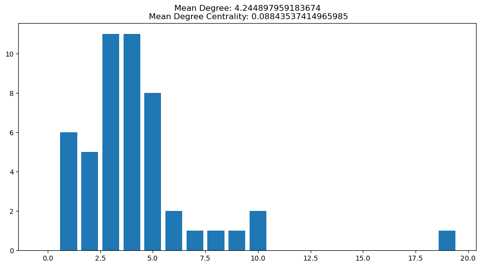

```python
import matplotlib.pyplot as plt
import numpy as np

histdegree = pd.DataFrame(nx.degree_histogram(nx_graph))
degree = dict(nx.degree(nx_graph))


mean_degree = np.mean(list(degree.values()))
mean_degree_centrality = np.mean(list(nx.degree_centrality(nx_graph).values()))

fig, ax = plt.subplots(figsize=(12,6))
ax.bar(histdegree.index.values,histdegree[0])

plt.title("Mean Degree: {n1}\n Mean Degree Centrality: {n2}".format(n1=mean_degree,n2=mean_degree_centrality))
plt.show()
```

Another very useful measure is the clustering coefficient, which tells us how likely the nodes are to build clusters. This is a global measure, but can also be calculated for each node.

```python
print("Clustering coefficient: {n}".format(n=nx.average_clustering(nx_graph)))
```

```
Clustering coefficient: 0.10599543075375514
```

### Exercise 3

As a second step, take some time to explore the documentation of networkx. Is there something other you can calculate and learn about the graph?

```python
nx_graph.is_directed()
```

```
True
```

```python
#closeness centrality 1. How easily can this node reach others?
cc_out= nx.closeness_centrality(nx_graph)
```

```python
#closeness centrality 2. how easily can others reach this node?
cc_in = nx.closeness_centrality(nx_graph.reverse(copy=False))
```

```python
#closeness centrality 3. ignore direction because direction mainly reflect subject-object orientation of
# triples rather then the flow of process. Doing closeness centrality on a undirected graph therefore gives a
# much better picture of closeness

cc_und = nx.closeness_centrality(nx_graph.to_undirected())
cc_und
```

```
{rdflib.term.BNode('Nfc07a975edea44ff9bc7832dbdf8dbdf'): 0.29002192982456143,
 rdflib.term.BNode('N0987167a11004ce3b38160c8ca6bc9c2'): 0.390117994100295,
 rdflib.term.URIRef('http://example.org/music_ontology.owl#authorOf'): 0.390117994100295,
 rdflib.term.URIRef('http://example.org/music_ontology.owl#Song'): 0.390117994100295,
 rdflib.term.URIRef('http://example.org/music_ontology.owl#Album'): 0.38669590643274854,
 rdflib.term.URIRef('http://www.w3.org/2002/07/owl#Thing'): 0.42799352750809067,
 rdflib.term.URIRef('http://example.org/music_ontology.owl#writtenBy'): 0.3241421568627451,
 rdflib.term.URIRef('http://example.org/music_ontology.owl#hasFan'): 0.390117994100295,
 rdflib.term.URIRef('http://example.org/music_ontology.owl#Artist'): 0.5580168776371308,
 rdflib.term.URIRef('http://example.org/music_ontology.owl#Drake'): 0.3126477541371159,
 rdflib.term.URIRef('http://example.org/music_ontology.owl#SoloArtist'): 0.40075757575757576,
 rdflib.term.URIRef('http://example.org/music_ontology.owl#CollaboratingArtist'): 0.4238782051282051,
 rdflib.term.URIRef('http://example.org/music_ontology.owl#albumID'): 0.3019406392694064,
 rdflib.term.URIRef('http://www.w3.org/2002/07/owl#Class'): 0.45920138888888895,
 rdflib.term.URIRef('http://example.org/music_ontology.owl#collaboratesWith'): 0.39714714714714716,
 rdflib.term.URIRef('http://www.w3.org/2002/07/owl#SymmetricProperty'): 0.2825854700854701,
 rdflib.term.URIRef('http://example.org/music_ontology.owl#miss_lauren_hill'): 0.38333333333333336,
 rdflib.term.BNode('Nd9d1fde78a534f0c9877466e86760900'): 0.40075757575757576,
 rdflib.term.URIRef('http://example.org/music_ontology.owl#kill_bill'): 0.3526666666666667,
 rdflib.term.URIRef('http://example.org/music_ontology.owl#createdBy'): 0.390117994100295,
 rdflib.term.URIRef('http://www.w3.org/2002/07/owl#ObjectProperty'): 0.3704481792717087,
 rdflib.term.URIRef('http://www.w3.org/2002/07/owl#Restriction'): 0.2998866213151928,
 rdflib.term.URIRef('http://example.org/music_ontology.owl#hasArtist'): 0.40443425076452605,
 rdflib.term.URIRef('http://example.org/music_ontology.owl#hasName'): 0.30402298850574716,
 rdflib.term.URIRef('http://www.w3.org/2002/07/owl#DatatypeProperty'): 0.3104460093896714,
 rdflib.term.BNode('N72da62f661674c5e836dcc1c71b71733'): 0.37358757062146897,
 rdflib.term.URIRef('http://example.org/music_ontology.owl#SZA'): 0.4238782051282051,
 rdflib.term.URIRef('http://example.org/music_ontology.owl#isOfAlbum'): 0.34711286089238846,
 rdflib.term.URIRef('http://example.org/music_ontology.owl#Person'): 0.34711286089238846,
 rdflib.term.URIRef('http://www.w3.org/2002/07/owl#NamedIndividual'): 0.32654320987654323,
 rdflib.term.URIRef('http://example.org/music_ontology.owl#SOS'): 0.3498677248677249,
 rdflib.term.URIRef('http://example.org/music_ontology.owl#ArtistType'): 0.390117994100295,
 rdflib.term.URIRef('http://example.org/music_ontology.owl#hasArtistSong'): 0.38669590643274854,
 rdflib.term.URIRef('http://example.org/music_ontology.owl#isFanOf'): 0.390117994100295,
 rdflib.term.BNode('N81c00e8cf75b441782554913e91c85fb'): 0.3391025641025641,
 rdflib.term.URIRef('http://www.w3.org/2001/XMLSchema#string'): 0.2577972709551657,
 rdflib.term.URIRef('http://example.org/music_ontology.owl#SubGenre'): 0.3217761557177615,
 rdflib.term.URIRef('http://example.org/music_ontology.owl#Genre'): 0.331453634085213,
 rdflib.term.URIRef('http://www.w3.org/1999/02/22-rdf-syntax-ns#nil'): 0.22377326565143826,
 rdflib.term.URIRef('http://example.org/music_ontology.owl#albumName'): 0.29786036036036034,
 rdflib.term.URIRef('http://example.org/music_ontology.owl#isOfGenre'): 0.31714628297362113,
 rdflib.term.URIRef('http://example.org/music_ontology.owl#artistName'): 0.38669590643274854,
 rdflib.term.URIRef('http://example.org/music_ontology.owl#followers'): 0.39360119047619047,
 rdflib.term.URIRef('http://example.org/music_ontology.owl#Fie'): 0.31714628297362113,
 rdflib.term.URIRef('http://www.w3.org/2002/07/owl#FunctionalProperty'): 0.29786036036036034,
 rdflib.term.Literal('1', datatype=rdflib.term.URIRef('http://www.w3.org/2001/XMLSchema#nonNegativeInteger')): 0.28440860215053765,
 rdflib.term.URIRef('http://example.org/music_ontology.owl'): 0.020833333333333332,
 rdflib.term.URIRef('http://www.w3.org/2002/07/owl#Ontology'): 0.020833333333333332,
 rdflib.term.URIRef('http://www.w3.org/2001/XMLSchema#integer'): 0.2807855626326964}
```

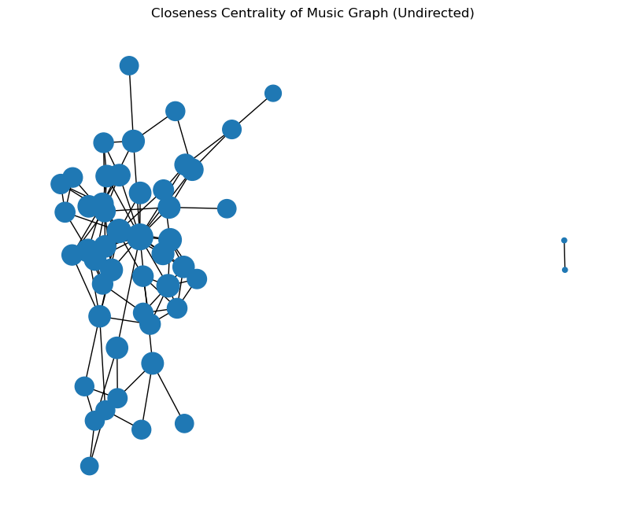

```python
pos = nx.spring_layout(nx_graph.to_undirected(), seed=42)

# Scale node sizes by centrality (so differences are visible)
node_sizes = [cc_und[n] * 1000 for n in nx_graph.to_undirected().nodes()]

plt.figure(figsize=(10, 8))
nx.draw_networkx(
    nx_graph.to_undirected(),
    pos,
    node_size=node_sizes,
    with_labels=False,
)

plt.title("Closeness Centrality of Music Graph (Undirected)")
plt.axis("off")
plt.show()
```

## 4. Visualizing your graph

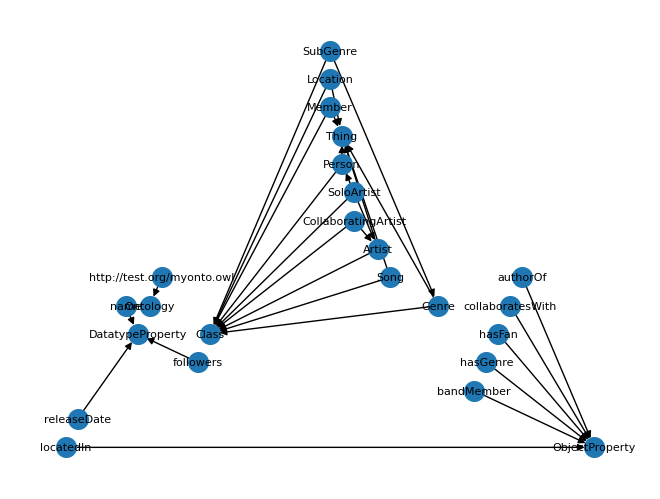

```python
# list(nx_graph.nodes())

music_ontology = rdflib.Graph()
music_ontology.parse("data/music_onto_simple.rdf")
nx_graph = rdflib_to_networkx_digraph(music_ontology)


mapping = pd.DataFrame(nx_graph.nodes())
mapping['new_names'] = mapping[0].str.split("#",n=1,expand=False)
mapping['label'] = 'NA'
# print(mapping)
mapping_copy = mapping.copy()

for ind, m in mapping_copy.iterrows():
    l = len(m['new_names'])
    names = m['new_names']
    mapping.loc[ind,'label'] = names[l-1]

map_dict = dict(zip(mapping[0],mapping['label']))

# print(mapping)
nx_graph_nl = nx.relabel_nodes(nx_graph,map_dict,copy=True)


nx.draw_planar(nx_graph_nl,
                 with_labels=True,
                node_size=200, font_size=8 )
# plt.draw()
```

### Exercise 4

Try to visualize the Hybrid Intelligence ontology below. Don't shy away from looking for and trying other approaches to visualize an ontology, giving nodes different colors, or varying thickness/color of the edges based on the type of relation.

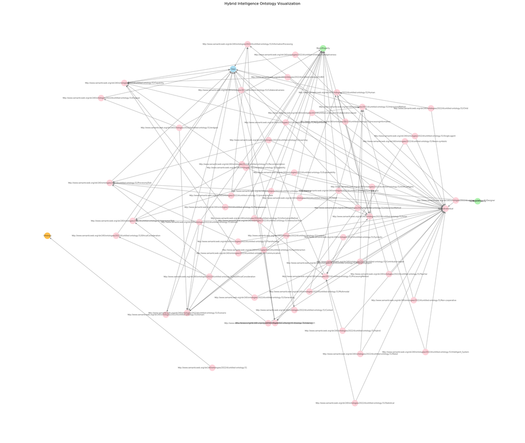

```python
hi_ontology = rdflib.Graph()
hi_ontology.parse("data/hi_ontology.nt")
nx_hi_graph = rdflib_to_networkx_digraph(hi_ontology)
nodes_to_remove = [n for n in nx_hi_graph.nodes() if isinstance(n, Literal)]
nx_hi_graph.remove_nodes_from(nodes_to_remove)

mapping = pd.DataFrame(nx_hi_graph.nodes())
mapping['new_names'] = mapping[0].astype(str).str.split("#", n=1, expand=False)
mapping['label'] = 'NA'

for ind, m in mapping.iterrows():
    mapping.loc[ind, 'label'] = m['new_names'][-1]

map_dict = dict(zip(mapping[0], mapping['label']))
G = nx.relabel_nodes(nx_hi_graph, map_dict, copy=True)

node_colors = []
for node in G.nodes():
    if "Class" in node:
        node_colors.append("skyblue")
    elif "Property" in node:
        node_colors.append("lightgreen")
    elif "Ontology" in node:
        node_colors.append("orange")
    else:
        node_colors.append("pink")

plt.figure(figsize=(24, 20))

pos = nx.spring_layout(G, seed=42, k=0.5)

nx.draw(
    G,
    pos,
    with_labels=True,
    node_color=node_colors,
    node_size=400,
    font_size=6,
    edge_color="gray",
    alpha=0.7
)

plt.title("Hybrid Intelligence Ontology Visualization")
plt.axis("off")
plt.show()
```

## 5. Clustering

NetworkX already comes with some clustering algorithms. We will try the one introduced in the theory part of the class, Louvain clustering algorithm.

```python
import networkx.algorithms.community as nx_comm


communities = nx_comm.louvain_communities(nx_graph,resolution=1)
print(1,len(communities),nx.number_of_nodes(nx_graph))
```

```
1 5 24
```

Now we can visualize the graph and the communities within it. Alternatively you can also visualize a community as an example alone. (WARNING: this might take a while...)

[output not shown]

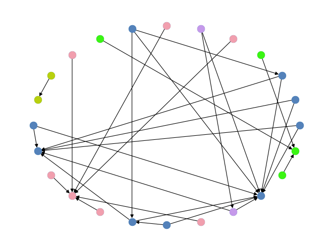

```python
pos = nx.shell_layout(nx_graph)


nx.draw(nx_graph, pos, edge_color='k',font_weight='light',
        node_size= 100, width= 0.8)
for com in communities:
    nx.draw_networkx_nodes(nx_graph,
                           pos,
                           nodelist=com,
                           node_color=np.random.rand(3,),
                           node_size=100)
plt.show()
```

If clustering is successful and helpful is very dependent on your graph. It is beneficial to remove the information from your graph that is not helpful for the clustering, like the T-box of your ontology, as this "polutes" the graph. The clustering algorithm is not made for knowledge graphs but rather for mathematical graphs, hence less semantics is better.

### Exercise 5

Try to cluster your own graph. You might have to create a mathematical graph first, rather than just converting your knowledge graph, as that will lead to better and more insightful results.

```python
from networkx.algorithms.community import greedy_modularity_communities
G = nx_hi_graph

nodes_to_remove = [n for n in G.nodes() if isinstance(n, Literal)]
G_clean = G.copy()
G_clean.remove_nodes_from(nodes_to_remove)

tbox_keywords = ["Class", "Property", "Ontology"]
nodes_to_remove = [n for n in G_clean.nodes()
                   if any(k in str(n) for k in tbox_keywords)]

G_clean.remove_nodes_from(nodes_to_remove)

G_math = G_clean.to_undirected()
communities = list(greedy_modularity_communities(G_math))
```

[figure not shown]

```python
pos = nx.shell_layout(G_math)

plt.figure(figsize=(12, 10))

nx.draw(G_math, pos,
        edge_color='k',
        font_weight='light',
        node_size=100,
        width=0.5,
        with_labels=False)

for com in communities:
    nx.draw_networkx_nodes(
        G_math,
        pos,
        nodelist=list(com),
        node_color=np.random.rand(3,),
        node_size=120
    )

plt.title("Clustering of Cleaned Music Graph")
plt.show()
```